# Examen Final Bioinformatica

### Pregunta 2: Visualización de datos

#### 2.1 Cree la funcion tcga_boxplots para visualizar boxplots y jitterplots. El único parámetro de la función es dataset. La función debe crear un boxplot de los niveles de expresión para cada gen.

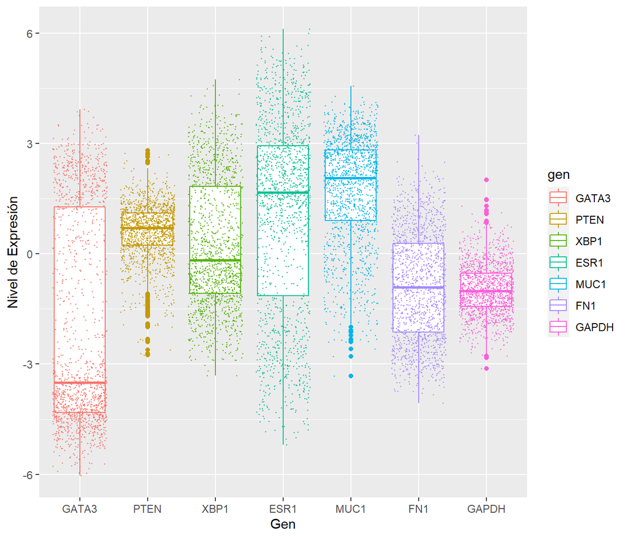

```r
# Escriba el código para crear la función tcga_boxplots
library(ggplot2)
box_tcg <- function(dataset) {
  library(ggplot2)
  return(ggplot (dataset, aes(x = gen, y = expresion_level, col = gen)) + labs(x="Gen", y = "Nivel de Expresión")
         + geom_boxplot() + geom_jitter(size=0.15))
}
box_tcg(df_long)
```

#### 2.2 Utilizando la función lapply() genera la lista cancertype_boxplots con las gráficas para cada tipo de cancer (cada tipo de dataset).

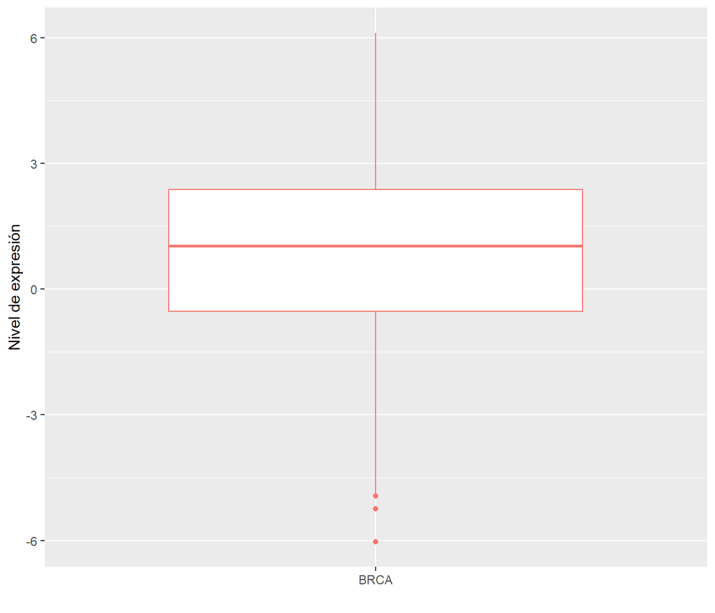

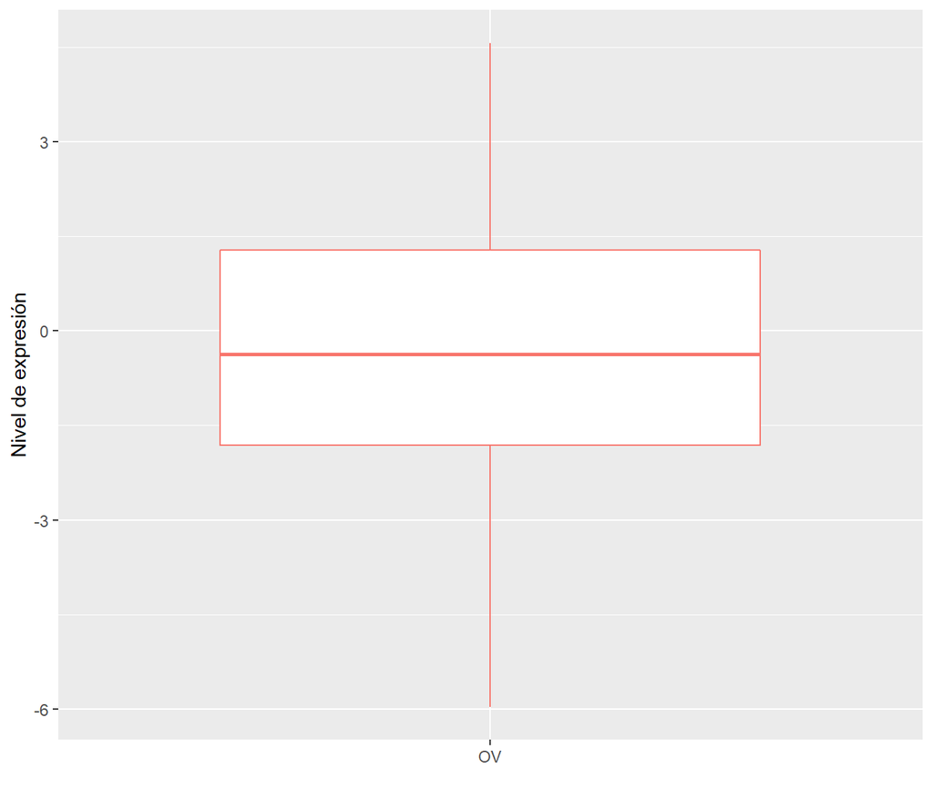

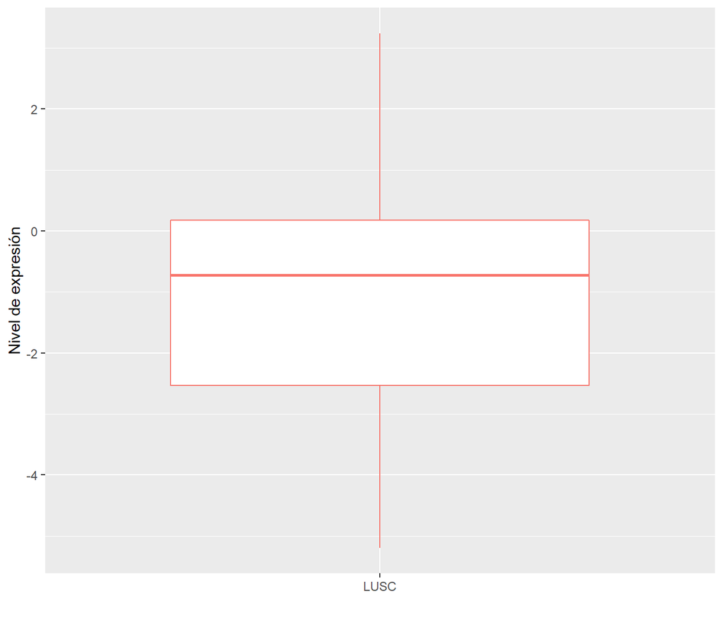

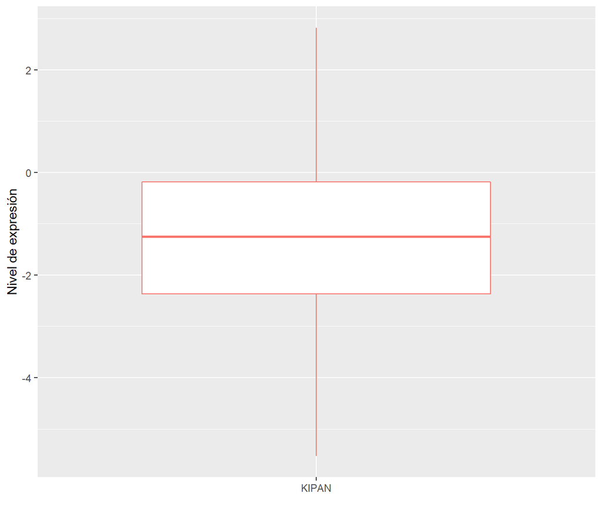

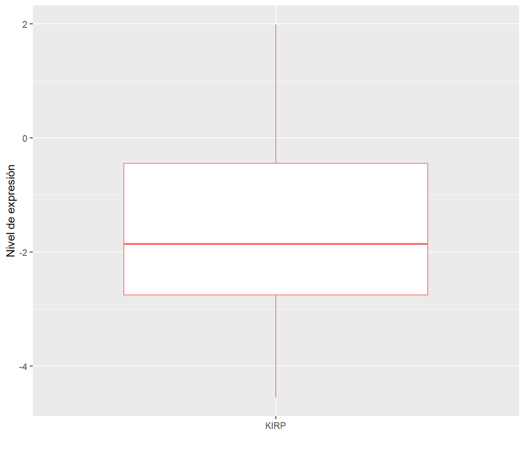

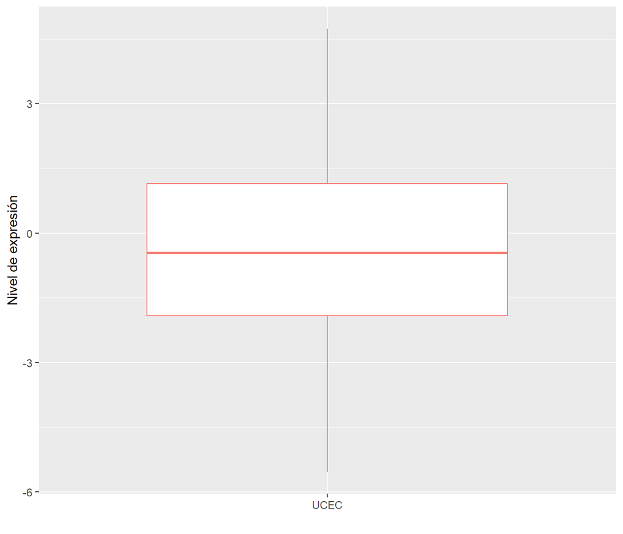

```r
# Escriba el código para generar la lista.
TiposdeCA <- list(
  BRCA <- filter(df_long, dataset == "BRCA"),
  OV <- filter(df_long, dataset == "OV"),
  LUSC <- filter(df_long, dataset == "LUSC"),
  KIPAN <- filter(df_long, dataset == "KIPAN"),
  KIRP <- filter(df_long, dataset == "KIRP"),
  UCEC <- filter(df_long, dataset == "UCEC")
)
TiposdeCABoxplot = lapply(TiposdeCA, function(x) {ggplot(x, aes(dataset, expresion_level, col = dataset)) +
    geom_boxplot() + theme(legend.position='none') + labs(x = "", y = "Nivel de expresión")})
TiposdeCABoxplot
```

#### 2.3 Guarde en el subdirectorio result el tercer plot de la lista cancertype_boxplots con el nombre boxplot3.png. La definición de a figura debe ser de 300dpi.

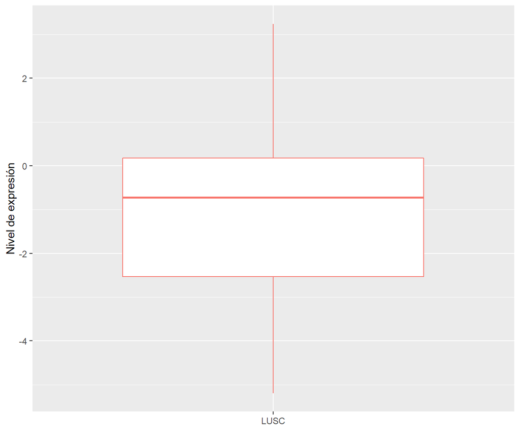

```r
# Escriba el código para guardar la tercera figura de la lista.
TiposdeCABoxplot[3]
```

```r
ggsave("D:/Documentos/GitHub/GBI6_ExamenFinal/results/boxplot3.png", width = 8, height = 10, dpi = 300)
```

#### 2.4 Escriba la función reg_gen_expression, con el parámetro gen. En este caso la función visualizará una gráfica de nube de puntos (geom_point) y una regresión por tipo de “dataset”. La gráfica será de comparación de gen1 con gen2; por ejemplo en el eje “x” GATA3 y en el eje “y”” FN1.

```r
# Escriba aquí su función reg_gen_expression
tdataset <- list(BRCA <- filter(df_long, dataset == "BRCA"), OV <- filter(df_long, dataset == "OV"),
    LUSC <- filter(df_long, dataset == "LUSC"),
    KIPAN <- filter(df_long, dataset == "KIPAN"),
    KIRP <- filter(df_long, dataset == "KIRP"),
    UCEC <- filter(df_long, dataset == "UCEC"),
    GAPDH <- filter(df_long, dataset == "GAPDH")
  )

graficoscancer <- list (
  BRCA_1 <- BRCA %>% group_by(gen) %>% mutate(row = row_number()) %>%
    tidyr::pivot_wider(names_from = gen, values_from = expresion_level) %>%
    select(-row),
  OV_1 <- OV %>% group_by(gen) %>% mutate(row = row_number()) %>%
    tidyr::pivot_wider(names_from = gen, values_from = expresion_level) %>%
    select(-row),
  LUSC_1 <- LUSC %>% group_by(gen) %>% mutate(row = row_number()) %>%
    tidyr::pivot_wider(names_from = gen, values_from = expresion_level) %>%
    select(-row),
  KIPAN_1 <- KIPAN %>% group_by(gen) %>% mutate(row = row_number()) %>%
    tidyr::pivot_wider(names_from = gen, values_from = expresion_level) %>%
    select(-row),
  KIRP_1 <- KIRP %>% group_by(gen) %>% mutate(row = row_number()) %>%
    tidyr::pivot_wider(names_from = gen, values_from = expresion_level) %>%
    select(-row),
  UCEC_1 <- UCEC %>% group_by(gen) %>% mutate(row = row_number()) %>%
    tidyr::pivot_wider(names_from = gen, values_from = expresion_level) %>%
    select(-row),
  GAPH_1 <- UCEC %>% group_by(gen) %>% mutate(row = row_number()) %>%
    tidyr::pivot_wider(names_from = gen, values_from = expresion_level) %>%
    select(-row)
)
```

#### 2.5. Utilizando la función lapply() genera la lista reg_genplots con las gráficas para cada par de genes posibles. Recuerde que tiene 7 tipos de genes, se debe tener todas las combinaciones posibles por pares de genes (combinatoria sin repetición).

```r
# Escriba el código para generar la lista.
E_G_R <- function (gen) {
  if (gen == "GATA3"){
    total <- list (
      lapply(graficoscancer, function(x) {ggplot(x, aes(GATA3, PTEN)) +
          geom_point() + geom_smooth(method='lm', formula= y~x)}),
      lapply(graficoscancer, function(x) {ggplot(x, aes(GATA3, XBP1)) +
          geom_point() + geom_smooth(method='lm', formula= y~x)}),
      lapply(graficoscancer, function(x) {ggplot(x, aes(GATA3, ESR1)) +
          geom_point() + geom_smooth(method='lm', formula= y~x)}),
      lapply(graficoscancer, function(x) {ggplot(x, aes(GATA3, MUC1)) +
          geom_point() + geom_smooth(method='lm', formula= y~x)}),
      lapply(graficoscancer, function(x) {ggplot(x, aes(GATA3, FN1)) +
          geom_point() + geom_smooth(method='lm', formula= y~x)}),
      lapply(graficoscancer, function(x) {ggplot(x, aes(GATA3, GAPDH)) +
          geom_point() + geom_smooth(method='lm', formula= y~x)}))
    }
  else if (gen == "PTEN"){
    total <- list (
      lapply(graficoscancer, function(x) {ggplot(x, aes(PTEN, GATA3)) +
          geom_point() + geom_smooth(method='lm', formula= y~x)}),
      lapply(graficoscancer, function(x) {ggplot(x, aes(PTEN, XBP1)) +
          geom_point() + geom_smooth(method='lm', formula= y~x)}),
      lapply(graficoscancer, function(x) {ggplot(x, aes(PTEN, ESR1)) +
          geom_point() + geom_smooth(method='lm', formula= y~x)}),
      lapply(graficoscancer, function(x) {ggplot(x, aes(PTEN, MUC1)) +
          geom_point() + geom_smooth(method='lm', formula= y~x)}),
      lapply(graficoscancer, function(x) {ggplot(x, aes(PTEN, FN1)) +
          geom_point() + geom_smooth(method='lm', formula= y~x)}),
      lapply(graficoscancer, function(x) {ggplot(x, aes(PTEN, GAPDH)) +
          geom_point() + geom_smooth(method='lm', formula= y~x)}))
  }
  else if (gen == "XBP1"){
    total <- list (
      lapply(graficoscancer, function(x) {ggplot(x, aes(XBP1, GATA3)) +
          geom_point() + geom_smooth(method='lm', formula= y~x)}),
      lapply(graficoscancer, function(x) {ggplot(x, aes(XBP1, PTEN)) +
          geom_point() + geom_smooth(method='lm', formula= y~x)}),
      lapply(graficoscancer, function(x) {ggplot(x, aes(XBP1, ESR1)) +
          geom_point() + geom_smooth(method='lm', formula= y~x)}),
      lapply(graficoscancer, function(x) {ggplot(x, aes(XBP1, MUC1)) +
          geom_point() + geom_smooth(method='lm', formula= y~x)}),
      lapply(graficoscancer, function(x) {ggplot(x, aes(XBP1, FN1)) +
          geom_point() + geom_smooth(method='lm', formula= y~x)}),
      lapply(graficoscancer, function(x) {ggplot(x, aes(XBP1, GAPDH)) +
          geom_point() + geom_smooth(method='lm', formula= y~x)}))
  }
  else if (gen == "ESR1"){
    total <- list (
      lapply(graficoscancer, function(x) {ggplot(x, aes(ESR1, GATA3)) +
          geom_point() + geom_smooth(method='lm', formula= y~x)}),
      lapply(graficoscancer, function(x) {ggplot(x, aes(ESR1, PTEN)) +
          geom_point() + geom_smooth(method='lm', formula= y~x)}),
      lapply(graficoscancer, function(x) {ggplot(x, aes(ESR1, XBP1)) +
          geom_point() + geom_smooth(method='lm', formula= y~x)}),
      lapply(graficoscancerr, function(x) {ggplot(x, aes(ESR1, MUC1)) +
          geom_point() + geom_smooth(method='lm', formula= y~x)}),
      lapply(graficoscancer, function(x) {ggplot(x, aes(ESR1, FN1)) +
          geom_point() + geom_smooth(method='lm', formula= y~x)}),
      lapply(graficoscancer, function(x) {ggplot(x, aes(ESR1, GAPDH)) +
          geom_point() + geom_smooth(method='lm', formula= y~x)}))
  }
  else if (gen == "MUC1"){
    total <- list (
      lapply(graficoscancer, function(x) {ggplot(x, aes(MUC1, GATA3)) +
          geom_point() + geom_smooth(method='lm', formula= y~x)}),
      lapply(graficoscancer, function(x) {ggplot(x, aes(MUC1, PTEN)) +
          geom_point() + geom_smooth(method='lm', formula= y~x)}),
      lapply(graficoscancer, function(x) {ggplot(x, aes(MUC1, XBP1)) +
          geom_point() + geom_smooth(method='lm', formula= y~x)}),
      lapply(graficoscancer, function(x) {ggplot(x, aes(MUC1, ESR1)) +
          geom_point() + geom_smooth(method='lm', formula= y~x)}),
      lapply(graficoscancer, function(x) {ggplot(x, aes(MUC1, FN1)) +
          geom_point() + geom_smooth(method='lm', formula= y~x)}),
      lapply(graficoscancer, function(x) {ggplot(x, aes(MUC1, GAPDH)) +
          geom_point() + geom_smooth(method='lm', formula= y~x)}))
  }
  else if (gen == "FN1"){
    total <- list (
      lapply(graficoscancer, function(x) {ggplot(x, aes(FN1, GATA3)) +
          geom_point() + geom_smooth(method='lm', formula= y~x)}),
      lapply(graficoscancer, function(x) {ggplot(x, aes(FN1, PTEN)) +
          geom_point() + geom_smooth(method='lm', formula= y~x)}),
      lapply(graficoscancer, function(x) {ggplot(x, aes(FN1, XBP1)) +
          geom_point() + geom_smooth(method='lm', formula= y~x)}),
      lapply(graficoscancer, function(x) {ggplot(x, aes(FN1, ESR1)) +
          geom_point() + geom_smooth(method='lm', formula= y~x)}),
      lapply(graficoscancer, function(x) {ggplot(x, aes(FN1, MUC1)) +
          geom_point() + geom_smooth(method='lm', formula= y~x)}),
      lapply(graficoscancer, function(x) {ggplot(x, aes(FN1, GAPDH)) +
          geom_point() + geom_smooth(method='lm', formula= y~x)}))
  }
  else if (gen == "GAPDH"){
    total <- list (
      lapply(graficoscancer, function(x) {ggplot(x, aes(GAPDH, GATA3)) +
          geom_point() + geom_smooth(method='lm', formula= y~x)}),
      lapply(graficoscancer, function(x) {ggplot(x, aes(GAPDH, PTEN)) +
          geom_point() + geom_smooth(method='lm', formula= y~x)}),
      lapply(graficoscancer, function(x) {ggplot(x, aes(GAPDH, XBP1)) +
          geom_point() + geom_smooth(method='lm', formula= y~x)}),
      lapply(graficoscancer, function(x) {ggplot(x, aes(GAPDH, ESR1)) +
          geom_point() + geom_smooth(method='lm', formula= y~x)}),
      lapply(graficoscancer, function(x) {ggplot(x, aes(GAPDH, MUC1)) +
          geom_point() + geom_smooth(method='lm', formula= y~x)}),
      lapply(graficoscancer, function(x) {ggplot(x, aes(GAPDH, FN1)) +
          geom_point() + geom_smooth(method='lm', formula= y~x)}))
  }
}
```